# Project-1-Data-Exploration

#### Plot

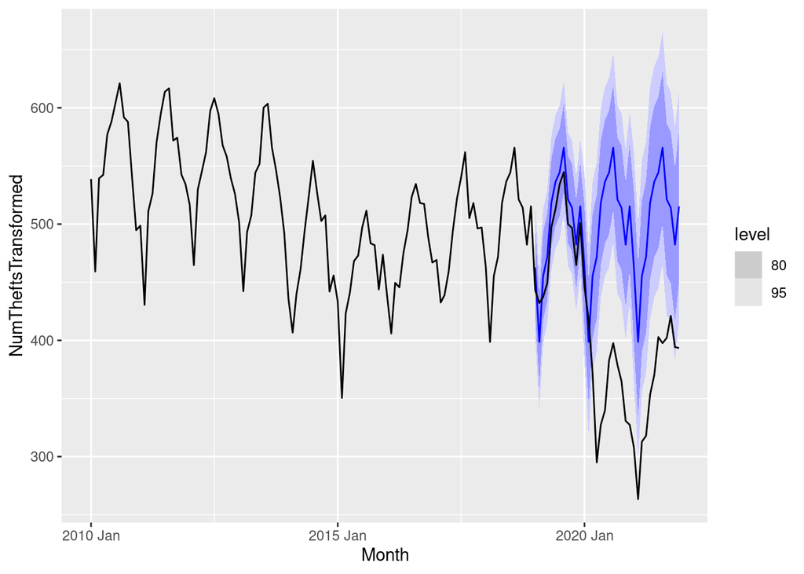

```r
raw_count.model.forecast %>%
  autoplot(thefts)
```

#### Tables

```r
raw_count.model.forecast %>%
  accuracy(thefts)
```

```
## # A tibble: 1 × 10
##   .model .type    ME  RMSE   MAE   MPE  MAPE  MASE RMSSE  ACF1
##   <chr>  <chr> <dbl> <dbl> <dbl> <dbl> <dbl> <dbl> <dbl> <dbl>
## 1 snaive Test  -95.2  119.  98.1 -26.9  27.6  4.19  4.06 0.881
```

## Forecasting Number of Thefts Per Capita

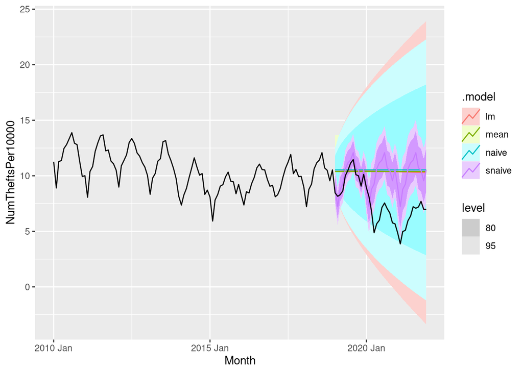

```r
percapita.model <- thefts_train %>%
  model(
    naive = NAIVE(NumTheftsPer10000),
    snaive = SNAIVE(NumTheftsPer10000),
    mean = MEAN(NumTheftsPer10000),
    lm = RW(NumTheftsPer10000 ~ drift()),

  )
percapita.model.forecast <- percapita.model %>%
  forecast(h = "3 years")
percapita.model.forecast %>%
  autoplot(thefts)
```

#### Plot

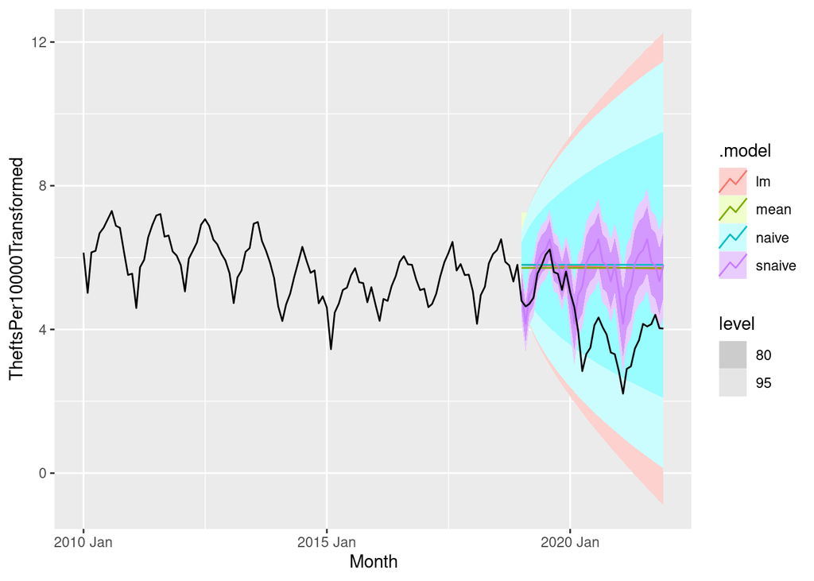

```r
percapita.model.t <- thefts_train %>%
  model(
    naive = NAIVE(TheftsPer10000Transformed),
    snaive = SNAIVE(TheftsPer10000Transformed),
    mean = MEAN(TheftsPer10000Transformed),
    lm = RW(TheftsPer10000Transformed ~ drift()),

  )
percapita.model.forecast <- percapita.model.t %>%
  forecast(h = "3 years")
percapita.model.forecast %>%
  autoplot(thefts)
```

```r
percapita.model.forecast %>%
  accuracy(thefts)
```

[output not shown]

#### Tables

```r
percapita.model.forecast %>%
  accuracy(thefts)
```

```
## # A tibble: 4 × 10
##   .model .type    ME  RMSE   MAE   MPE  MAPE  MASE RMSSE  ACF1
##   <chr>  <chr> <dbl> <dbl> <dbl> <dbl> <dbl> <dbl> <dbl> <dbl>
## 1 lm     Test  -1.47  1.76  1.51 -42.4  43.0  4.53  4.25 0.899
## 2 mean   Test  -1.44  1.75  1.49 -41.7  42.6  4.48  4.22 0.902
## 3 naive  Test  -1.53  1.82  1.57 -43.9  44.6  4.70  4.40 0.902
## 4 snaive Test  -1.30  1.63  1.35 -36.7  37.9  4.05  3.95 0.878
```

### Residuals of the Best Method

As I expected, the best performing model appears to be the seasonal naive model, across all measures. Now, I will look at the residuals to see whether they look like white noise.

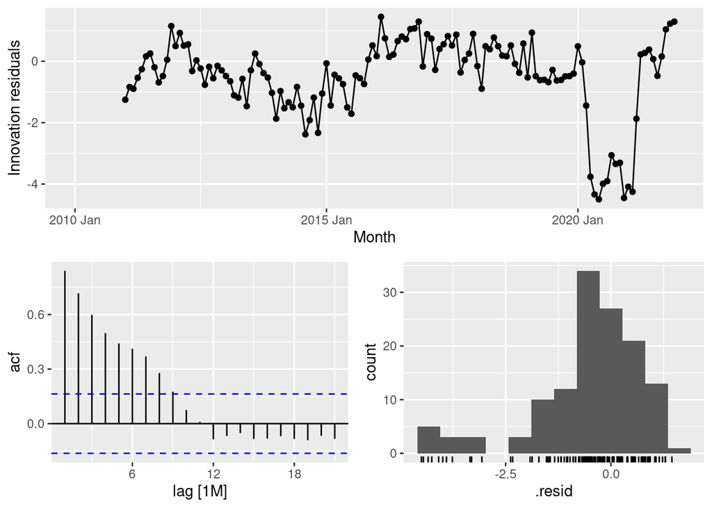

```r
raw_count.snaive <- thefts %>%
  model(
    snaive = SNAIVE(NumTheftsPer10000)
  )
raw_count.snaive %>%
  gg_tsresiduals()
```

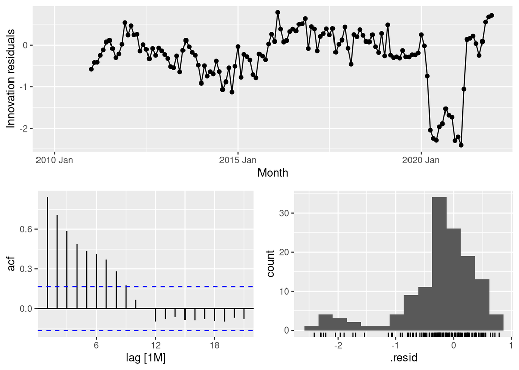

```r
raw_count.t.snaive <- thefts %>%
  model(
    snaive = SNAIVE(TheftsPer10000Transformed)
  )
raw_count.t.snaive %>%
  gg_tsresiduals()
```

There is still significant autocorrelation in these residuals, and the distribution looks slightly left skewed. Therefore, the seasonal naive method is not appropriate for predicting the number of thefts over time.

## Exploring the Unemployment Variable

This variable, taken from the Illinois website, explores the un-seasonally adjusted unemployment rate in Chicago.

### Original Variable

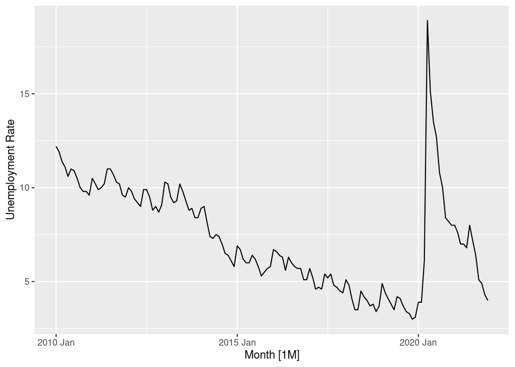

```r
thefts %>%
  autoplot(`Unemployment Rate`)
```

### Transformed using Box Cox

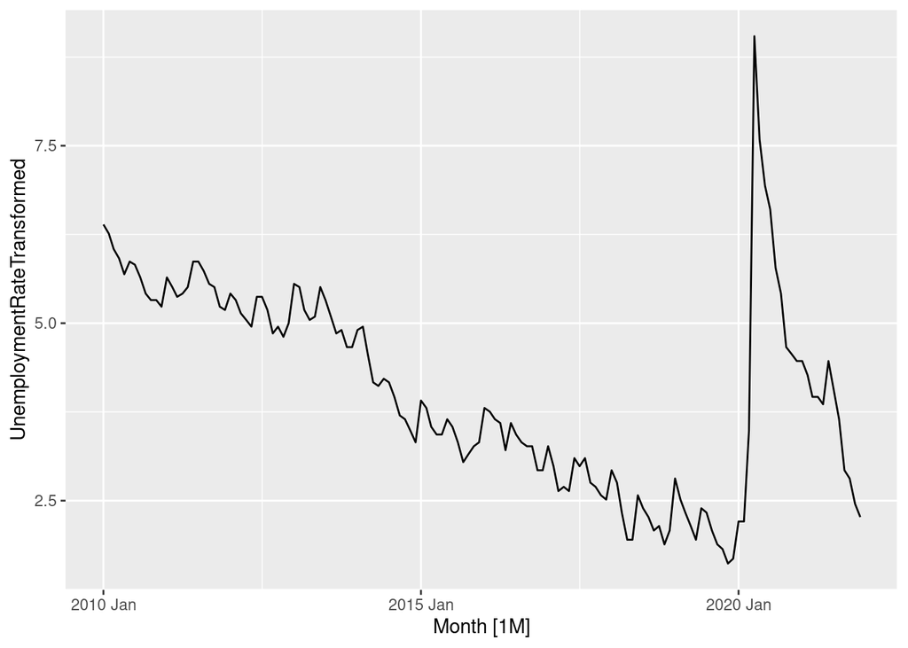

```r
lambda <- thefts |>
  features(NumThefts, features = guerrero) |>
  pull(lambda_guerrero)

thefts <- thefts %>%
  mutate(UnemploymentRateTransformed = box_cox(`Unemployment Rate`, lambda))
thefts %>%
  autoplot(UnemploymentRateTransformed)
```